[figure not shown]

Wisdom and AI Conference · Church Track

# Modeling Communities in Peril

Polarization and the changes in the social fabric of congregations through an agent-based approach

Eric Araújo

Friday, October 9, 2026

[figure not shown]

[figure not shown]

“That they may all be one.”

John 17:21

If we are united in Christ, why is there so much division?

Brazil, 1970 to 2022

## Churches multiplied as the Christian share fell

100%

50%

0%

1970

1980

1991

2000

2010

2022

All Christians 84%

Catholics 57%

Evangelicals 27%

96 → 84

Christians per 100 Brazilians, 1980 to 2022

17 a day

new evangelical churches registered in 2019 (6,356 that year)

Sources: IBGE censuses (2010 and 2022: population aged 10+); Victor Araújo, Centro de Estudos da Metrópole (USP), national business registry, 2019

Why stay?

Is a uniform congregation stronger, or only quieter?

Source: ACM Computing Classification System (2012), Artificial intelligence; adapted, with machine learning and robotics added

“Agentic AI”

## Agents are not new

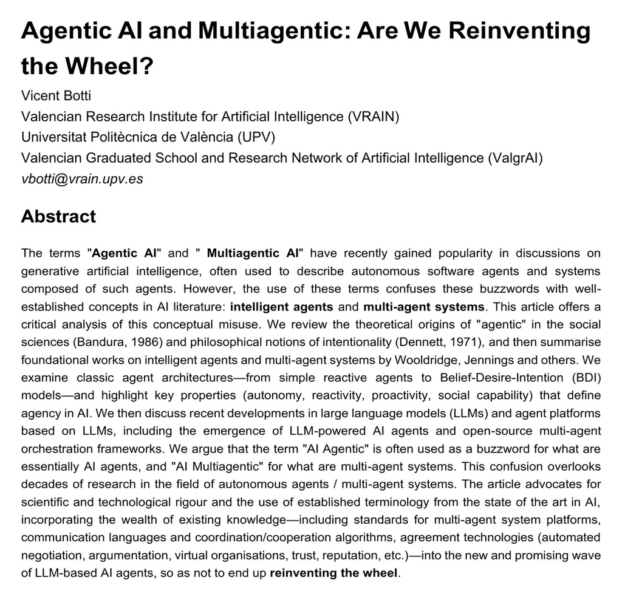

Vicent Botti, “Agentic AI and Multiagentic: Are We Reinventing the Wheel?”, arXiv:2506.01463, June 2025

[figure not shown]

“

There is no experimental mathematical proof available that our representations and concepts correspond to an objective reality.

Whoever desires such a proof prior to believing in an objective world of subjects and objects sets a condition that is in no way receptive to fulfillment.

Herman Bavinck, *Christian Worldview*

Herman Bavinck, Christian Worldview, trans. N. Gray Sutanto, James Eglinton and Cory C. Brock (Crossway, 2019), p. 42

[figure not shown]

Institution

Mystical communion

Sacrament

Herald

Servant

Community of disciples

Avery Dulles, Models of the Church (1974; expanded edition with the sixth model, 1987)

## The difference lies in the anthropology

### One axis among many

Age

Income

Ideology

Contacts

Religion

Commitment as a cost–benefit calculation or an identity marker

### Three dimensions of one person

Belief

Behavior

Belonging

Held together; none can stand in for the others

**Method** from the science of religion

+

**Anthropology** from theology

The Trifold model

The Trifold Community Model

## Belief, behavior, belonging

Behavior

who shows up, who talks to whom

Belief

political and religious positions

Belonging

read off the web of ties

encounters expose us to other views

showing up builds ties; ties bring us back

feelings toward others strengthen or fray ties

Polarization as

### A triadic wound

- to the sense of belonging
- to embodied habits of relationship
- to open-minded inquiry

No dimension is outside the others.

## An agent

### Belief

two positions: political and religious

### Behavior

shows up by belonging, friends, routine

### Belonging

[figure not shown]

a number derived from the ties

≠

≠

attends faithfully,  
ties thinning

ties intact,  
attendance lapsed

politics drifting

faith shifting

The version we are building now

## Three more decisions

Belonging is read  
off the ties

Feelings and beliefs, measured apart

One mechanism at a time

[figure not shown]

“

Among us unity exists only by attraction, by the will and the disposition of the will; it is a moral unity that is fragile and unstable.

Herman Bavinck, *Reformed Dogmatics*

Herman Bavinck, Reformed Dogmatics, vol. 2: God and Creation, ed. John Bolt, trans. John Vriend (Baker Academic, 2004), p. 331

Bavinck

## Two ways unity fails

Unity swallows diversity

uniform and brittle

Unity in diversity

the cohesion worth wanting

Diversity outruns unity

the congregation comes apart

## Built to travel

What a model could do for a church

See

belonging thinning at the edges

Ask

“what if?” before living it

hypotheses to test

Epistemic humility

“To go into the world and create some imperfect models of the good world to come.”

LEWIS SMEDES

Representations of the world as it now is, fallen and fragmented, built *for* the world to come.

What the model cannot see

## The model is silent about grace

[figure not shown]

the elder who stays

a sermon after a crisis

prayer

the movement of the Holy Spirit

What we do not measure is not thereby unimportant.

An invitation

## Friction does not have to become fracture

theologians

social scientists

pastors

modelers

We listen first.

“A great multitude that no one could number, from every nation, from all tribes and peoples and languages, standing before the throne and before the Lamb.”

Revelation 7:9

[figure not shown]

Thank you

Eric Araújo

Calvin University

ericaraujo.com

→ / Space / click: next · ← back · F: full screen